# Exercises_Admixture_Kenya26_WoA

Estimating admixture proportions

For this exercise we will again use data from the Blue Wildebeest. To simplify the analyses we have included only one of the Brindled wildebeest populations (B-Etosha). We have included one population from each of the five blue wildebeest subspecies,except for the eastern white-bearded wildebeest for which we included three populations.

[figure not shown]

# Software and data

### Software

We will be using plink, PCAone and ADMIXTURE for this exercise. First let's see if the software is installed by running the follwoing commands (don't worry if you get a warning of some sort):

```
echo --Programs that are installed:--
which admixture
which plink
which oldPCAone
which evalAdmix
```

[output not shown]

```
--Programs that are installed:--
/usr/bin/admixture
/usr/bin/plink
/usr/local/bin/oldPCAone
/usr/bin/evalAdmix
```

### Data sets

Next, let's make a folder in your home directory, then then we will copy the data into your folder.

```
# make folder (if it already exist then delete the content so you can start over)
mkdir -p ~/kenya2026
mkdir -p ~/kenya2026/admixture
rm -rf ~/kenya2026/admixture/*

# enter folder
cd ~/kenya2026/admixture


# copy all the input data files you need for the exercise
DATA_PATH=/course/kenya2026/ida/admix/inputdata/

cp -sf ${DATA_PATH}/* .

# list the files
echo --- files in folder ---
ls

# also set path for precomputed results that you need later
RESULTS_PATH=/course/kenya2026/ida/admix/precomputedres/
```

```
--- files in folder ---
blue_wildebeest_thin.bed  blue_wildebeest_thin.bim  blue_wildebeest_thin.fam
```

### The fam file

The genotype data is stored in binary plink files (*.bed,*.fam,*.bim). Lets first look into the fam file which described the individuals in the data

```
echo -- number of lines in fam file --
wc -l blue_wildebeest_thin.fam

echo -- first 10 lines fam file --
head blue_wildebeest_thin.fam

echo -- counts of populations/subspecies from first column of fam file --
cut -f1 -d" " blue_wildebeest_thin.fam | sort | uniq -c
```

```
-- number of lines in fam file --
73 blue_wildebeest_thin.fam
-- first 10 lines fam file --
E-Amboseli CTauKeS__698 0 0 0 -9
E-Amboseli CTauKeS__699 0 0 0 -9
E-Amboseli CTauKeS__700 0 0 0 -9
E-Amboseli CTauKeS__701 0 0 0 -9
E-Amboseli CTauKeS__702 0 0 0 -9
E-Amboseli CTauKeS__704 0 0 0 -9
E-Amboseli CTauKeS__705 0 0 0 -9
E-Amboseli CTauKeS__706 0 0 0 -9
E-Amboseli CTauKeS__707 0 0 0 -9
E-Nairobi CTauKeS__709 0 0 0 -9
-- counts of populations/subspecies from first column of fam file --
      6 B-Ethosha
      3 C-Luangwa
      9 E-Amboseli
     11 E-Monduli
     10 E-Nairobi
      6 N-Selous
     28 W-Serengeti
```

# The bim file

Now let's look into the bim file. This is the file that describes the different genetic variants in the data set.

```
echo -- number of lines in bim file --
wc -l blue_wildebeest_thin.bim

echo -e "\n-- first 10 lines bim file --"
echo -e "CHR\tvariantID CM\tPosition allele_1\t allele_2"
head blue_wildebeest_thin.bim

echo -e "\n-- counts number of variants per chromosone from the first column of bim file --"
echo \#Var Chromosome_name
cat blue_wildebeest_thin.bim | cut -f1  | uniq -c
```

```
-- number of lines in bim file --
990980 blue_wildebeest_thin.bim

-- first 10 lines bim file --
CHR	variantID CM	Position allele_1	 allele_2
1	1:24346	0	24346	C	A
1	1:27283	0	27283	A	C
1	1:29167	0	29167	A	G
1	1:34548	0	34548	A	G
1	1:35562	0	35562	A	T
1	1:35922	0	35922	T	C
1	1:37028	0	37028	C	T
1	1:39322	0	39322	G	A
1	1:52974	0	52974	G	A
1	1:56563	0	56563	A	T

-- counts number of variants per chromosone from the first column of bim file --
#Var Chromosome_name
  68999 1
  66358 2
  48520 4
  45498 5
  46745 6
  50149 7
  45339 8
  41591 9
  41285 10
  39690 11
  39076 12
  37933 13
  37387 14
  31725 15
  32895 16
  31831 17
  29372 18
  32197 19
  27537 20
  22190 21
  22329 22
  27006 23
  23486 24
  20876 25
  20764 26
  20423 27
  19165 28
  20614 29
```

Run the code below to start a quiz.

```
from jupyterquiz import display_quiz
display_quiz('https://raw.githubusercontent.com/popgenDK/courses/main/kenya2024/exercises/day3_PopulationStructure/admixture_quiz1.json')
```

## LD pruning

It is recommended that LD pruning is performed prior to running ADMIXTURE. This is often done on the whole set of individuals using plink, while assmuming that there is no population structure. However, we actually expect there could be lots of population structure in our data, as individuals come from many different localities. Therefore, we will us a new method, PCAone, that corrects for population structure using PCA. To perform LD pruning we will choose the number of PCAs needed which in this case is **-k=6** since we expect there are 7 different populations (6 PCs allows for modelling 7 populations), because each PC can split data into to groups. We will use a LD threshold of **r2=0.1** which removes variants that are in LD with any other variant with a correlation coefficent above 0.1. Since we don't want to calculate LD between all pairs of variants in the whole genome, we will estimate LD in a sliding window of size **1000000=1Mb**.

The commands to do so can be seen below.

```
oldPCAone -b blue_wildebeest_thin -k 6 --ld -o pcaone
oldPCAone -B pcaone.residuals --match-bim pcaone.mbim --ld-r2 0.1 --ld-bp 1000000 -o pcaone
```

```
Machine name: x86_64
Node name: emily
Operating system release: 6.8.0-110-generic
Operating system version: #110~22.04.1-Ubuntu SMP PREEMPT_DYNAMIC Fri Mar 27 12:43:08 UTC
Operating system name: Linux
 PCAone (v0.5.4)    https://github.com/Zilong-Li/PCAone
Options in effect:
oldPCAone -b blue_wildebeest_thin -k 6 --ld -o pcaone
[21/08/2026-07:21:11] program started
[21/08/2026-07:21:11] start parsing PLINK format
[21/08/2026-07:21:11] N (# samples): 73, M (# SNPs): 990980
[21/08/2026-07:21:12] done reading all data
[21/08/2026-07:21:12] initialize window-based RSVD (winSVD) with in-core
[21/08/2026-07:21:12] permuting data matrix by columns in place
[21/08/2026-07:21:15] running of epoch =  1, diff = 0.017536
[21/08/2026-07:21:17] running of epoch =  2, diff = 0.000368
[21/08/2026-07:21:18] running of epoch =  3, diff = 0.000253
[21/08/2026-07:21:20] running of epoch =  4, diff = 0.000086
PCAone winSVD converged but continues running to get S and V.
[21/08/2026-07:21:22] running of epoch =  5, diff = 0.000117
[21/08/2026-07:21:23] running of epoch =  6, diff = 0.000000
[21/08/2026-07:21:23] stops at epoch =  7
[21/08/2026-07:21:23] eigen vectors and values saved
[21/08/2026-07:21:23] ld-stats=0: calculate the ancestry adjusted LD matrix!
[21/08/2026-07:21:27] save matched sites in .mbim file and permutation mode is  1
[21/08/2026-07:21:27] the LD matrix and SNPs info are saved
[21/08/2026-07:21:27] PCAone - Randomized SVD done
[21/08/2026-07:21:27] total elapsed reading time:  0.455000 seconds
[21/08/2026-07:21:27] total elapsed wall time: 16.195000 seconds
[21/08/2026-07:21:27] have a nice day. bye!
Machine name: x86_64
Node name: emily
Operating system release: 6.8.0-110-generic
Operating system version: #110~22.04.1-Ubuntu SMP PREEMPT_DYNAMIC Fri Mar 27 12:43:08 UTC
Operating system name: Linux
 PCAone (v0.5.4)    https://github.com/Zilong-Li/PCAone
Options in effect:
oldPCAone -B pcaone.residuals --match-bim pcaone.mbim --ld-r2 0.1 --ld-bp 1000000 -o pcaone
[21/08/2026-07:21:27] program started
[21/08/2026-07:21:27] start parsing binary format
[21/08/2026-07:21:27] shape of input matrix (features x samples) is 990980x 73
[21/08/2026-07:21:27] run LD stuff
[21/08/2026-07:21:28] done reading all data
[21/08/2026-07:21:29] LD pruning, choose sites to be kept randomly or with high MAF? 1(random) : 0(high MAF). =>  0
[21/08/2026-07:21:31] total elapsed wall time: 3.340000 seconds
[21/08/2026-07:21:31] have a nice day. bye!
```

The software prints out a new list of variants that are now not in LD with each other. We will extract those sites using plink, and create a new plink file named blue_wildebeest_noLD.

```
ls
echo --number of variants to be kept --
wc -l pcaone.ld.prune.in

echo -e "\n --Extract variants using plink --"
plink --bfile blue_wildebeest_thin --extract pcaone.ld.prune.in --make-bed --out blue_wildebeest_noLD  --chr-set 29
```

```
blue_wildebeest_thin.bed  pcaone.eigvecs       pcaone.log
blue_wildebeest_thin.bim  pcaone.eigvecs2      pcaone.mbim
blue_wildebeest_thin.fam  pcaone.ld.prune.in   pcaone.residuals
pcaone.eigvals            pcaone.ld.prune.out  pcaone.sigvals
--number of variants to be kept --
37576 pcaone.ld.prune.in

 --Extract variants using plink --
PLINK v1.90b6 64-bit (26 May 2018)             www.cog-genomics.org/plink/1.9/
(C) 2005-2018 Shaun Purcell, Christopher Chang   GNU General Public License v3
Logging to blue_wildebeest_noLD.log.
Options in effect:
  --bfile blue_wildebeest_thin
  --chr-set 29
  --extract pcaone.ld.prune.in
  --make-bed
  --out blue_wildebeest_noLD

386830 MB RAM detected; reserving 193415 MB for main workspace.
990980 variants loaded from .bim file.
73 samples (0 males, 0 females, 73 ambiguous) loaded from .fam.
Ambiguous sex IDs written to blue_wildebeest_noLD.nosex .
--extract: 37576 variants remaining.
Using 1 thread (no multithreaded calculations invoked).
Before main variant filters, 73 founders and 0 nonfounders present.
Calculating allele frequencies... 10111213141516171819202122232425262728293031323334353637383940414243444546474849505152535455565758596061626364656667686970717273747576777879808182838485868788899091929394959697989 done.
Total genotyping rate is 0.998514.
37576 variants and 73 samples pass filters and QC.
Note: No phenotypes present.
--make-bed to blue_wildebeest_noLD.bed + blue_wildebeest_noLD.bim +
blue_wildebeest_noLD.fam ... 101112131415161718192021222324252627282930313233343536373839404142434445464748495051525354555657585960616263646566676869707172737475767778798081828384858687888990919293949596979899done.
```

- How many genetic variants are left after pruning for LD?

## ADMIXTURE

We are now ready to run ADMIXTURE. First, let's look at the options of the program.

```
admixture --help
```

```
****                   ADMIXTURE Version 1.3.0                  ****
****                    Copyright 2008-2015                     ****
****           David Alexander, Suyash Shringarpure,            ****
****                John  Novembre, Ken Lange                   ****
****                                                            ****
****                 Please cite our paper!                     ****
****   Information at www.genetics.ucla.edu/software/admixture  ****


  ADMIXTURE basic usage:  (see manual for complete reference)
    % admixture [options] inputFile K

  where:
    K is the number of populations; and
    inputFile may be:
      - a PLINK .bed file
      - a PLINK "12" coded .ped file

  Output will be in files inputBasename.K.Q, inputBasename.K.P

  General options:
    -jX          : do computation on X threads
    --seed=X     : use random seed X for initialization

  Algorithm options:
     -m=
    --method=[em|block]     : set method.  block is default

     -a=
    --acceleration=none   |
                   sqs<X> |
                   qn<X>      : set acceleration

  Convergence criteria:
    -C=X : set major convergence criterion (for point estimation)
    -c=x : set minor convergence criterion (for bootstrap and CV reestimates)

  Bootstrap standard errors:
    -B[X]      : do bootstrapping [with X replicates]
```

As can be seen in the code above, we need to input our plink file and we need to choose a number of ancestral populations to use. In our case, the most likely relevant number of assumed ancestral populations is 7 - one for each sampling locality. ADMIXTURE uses numeric optimisation based on a random starting guess of the parameters. Therefore, we will specify a seed for the random numbers, so that we can reproduce the results (else we will get a different result each time we run it).

To make is run faster we will use 10 CPU threads. Run the following ( will take several minutes).

```
ls blue_wildebeest_noLD*
```

```
blue_wildebeest_noLD.bed  blue_wildebeest_noLD.fam  blue_wildebeest_noLD.nosex
blue_wildebeest_noLD.bim  blue_wildebeest_noLD.log
```

```
admixture --seed 0 -j10 blue_wildebeest_noLD.bed 7

# if it it takes too long to run the command, we just copy the results using the following command
#cp ${RESULTS_PATH}/blue_wildebeest_noLD.7.[QP]  .
```

```
****                   ADMIXTURE Version 1.3.0                  ****
****                    Copyright 2008-2015                     ****
****           David Alexander, Suyash Shringarpure,            ****
****                John  Novembre, Ken Lange                   ****
****                                                            ****
****                 Please cite our paper!                     ****
****   Information at www.genetics.ucla.edu/software/admixture  ****

Parallel execution requested.  Will use 10 threads.
Random seed: 0
Point estimation method: Block relaxation algorithm
Convergence acceleration algorithm: QuasiNewton, 3 secant conditions
Point estimation will terminate when objective function delta < 0.0001
Estimation of standard errors disabled; will compute point estimates only.
Size of G: 73x37576
Performing five EM steps to prime main algorithm
1 (EM) 	Elapsed: 0.43	Loglikelihood: -3.6618e+06	(delta): 397263
2 (EM) 	Elapsed: 0.431	Loglikelihood: -3.61082e+06	(delta): 50979.8
3 (EM) 	Elapsed: 0.43	Loglikelihood: -3.58511e+06	(delta): 25716.2
4 (EM) 	Elapsed: 0.43	Loglikelihood: -3.5644e+06	(delta): 20700.8
5 (EM) 	Elapsed: 0.43	Loglikelihood: -3.54549e+06	(delta): 18915.9
Initial loglikelihood: -3.54549e+06
Starting main algorithm
1 (QN/Block) 	Elapsed: 1.418	Loglikelihood: -3.09679e+06	(delta): 448698
2 (QN/Block) 	Elapsed: 1.323	Loglikelihood: -2.99685e+06	(delta): 99941.2
3 (QN/Block) 	Elapsed: 1.344	Loglikelihood: -2.96267e+06	(delta): 34176.6
4 (QN/Block) 	Elapsed: 1.381	Loglikelihood: -2.94918e+06	(delta): 13494.1
5 (QN/Block) 	Elapsed: 1.432	Loglikelihood: -2.94189e+06	(delta): 7288.17
6 (QN/Block) 	Elapsed: 1.527	Loglikelihood: -2.93785e+06	(delta): 4043.59
7 (QN/Block) 	Elapsed: 1.434	Loglikelihood: -2.9359e+06	(delta): 1943.16
8 (QN/Block) 	Elapsed: 1.444	Loglikelihood: -2.93431e+06	(delta): 1597.02
9 (QN/Block) 	Elapsed: 1.442	Loglikelihood: -2.93372e+06	(delta): 582.471
10 (QN/Block) 	Elapsed: 1.416	Loglikelihood: -2.93345e+06	(delta): 273.44
11 (QN/Block) 	Elapsed: 1.468	Loglikelihood: -2.93336e+06	(delta): 88.0959
12 (QN/Block) 	Elapsed: 1.471	Loglikelihood: -2.93331e+06	(delta): 51.698
13 (QN/Block) 	Elapsed: 1.5	Loglikelihood: -2.93327e+06	(delta): 38.3945
14 (QN/Block) 	Elapsed: 1.477	Loglikelihood: -2.93326e+06	(delta): 13.3105
15 (QN/Block) 	Elapsed: 1.463	Loglikelihood: -2.93325e+06	(delta): 11.8762
16 (QN/Block) 	Elapsed: 1.506	Loglikelihood: -2.93324e+06	(delta): 9.12031
17 (QN/Block) 	Elapsed: 1.472	Loglikelihood: -2.9332e+06	(delta): 37.7101
```

[output cut: 38 more lines]

```
56 (QN/Block) 	Elapsed: 1.615	Loglikelihood: -2.93311e+06	(delta): 0.00178908
57 (QN/Block) 	Elapsed: 1.651	Loglikelihood: -2.93311e+06	(delta): 2.49916e-05
Summary:
Converged in 57 iterations (90.016 sec)
Loglikelihood: -2933110.025724
Fst divergences between estimated populations:
	Pop0	Pop1	Pop2	Pop3	Pop4	Pop5
Pop0
Pop1	0.363
Pop2	0.268	0.231
Pop3	0.435	0.394	0.239
Pop4	0.334	0.091	0.202	0.367
Pop5	0.310	0.176	0.182	0.351	0.140
Pop6	0.258	0.305	0.196	0.368	0.275	0.254
Writing output files.
```

```
# let see which files it produces
echo -- files sorted. last files are the most recent --
ls -r
```

```
-- files sorted. last files are the most recent --
pcaone.sigvals       pcaone.eigvecs              blue_wildebeest_noLD.fam
pcaone.residuals     pcaone.eigvals              blue_wildebeest_noLD.bim
pcaone.mbim          blue_wildebeest_thin.fam    blue_wildebeest_noLD.bed
pcaone.log           blue_wildebeest_thin.bim    blue_wildebeest_noLD.7.Q
pcaone.ld.prune.out  blue_wildebeest_thin.bed    blue_wildebeest_noLD.7.P
pcaone.ld.prune.in   blue_wildebeest_noLD.nosex
pcaone.eigvecs2      blue_wildebeest_noLD.log
```

You should find two files ending with * .7.Q and * .7.P respectively. These are the estimated ancestry proportions and allele frequencies in the 7 inferred populations.

### Plotting admixture proportions

Let's plot the results. For this we will use R.

```
#make plot wide
library("repr")
options(repr.plot.width=17, repr.plot.height=4.5)

#read in code to plot admixture proportions ( plotAdmix function)
source("https://raw.githubusercontent.com/GenisGE/evalAdmix/master/visFuns.R")

# Read in inferred admixture proportions
q <- read.table("~/kenya2026/admixture/blue_wildebeest_noLD.7.Q")

#read in the population labels (first column of fam file)
table(pop <- read.table("~/kenya2026/admixture/blue_wildebeest_noLD.fam")[,1])

#plot admixture proportions
plotAdmix(q,pop=pop,rotatelab=15,padj=0.15,cex.lab=1.4,col=2:8)
legend(0,1.1,fill=2:8,legend=0:5,hor=T,xpd=T)
```

```
  B-Ethosha   C-Luangwa  E-Amboseli   E-Monduli   E-Nairobi    N-Selous
          6           3           9          11          10           6
W-Serengeti
         28
```

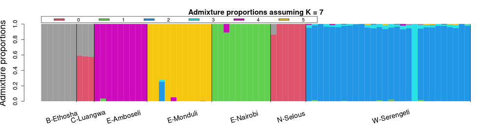

- Does the results look like you expect (why/why not)?

There are several hints that the results might be wrong. For example, do you think it is realistic that the 3 Cookson's wildebeest samples ('C-Luangwa') are all truly admixed with more or less the same admixture proportions?

### EvalAdmix to the rescue

To solve this challenge, we can use evalAdmix to diagnose problems with the results of the analysis. This method uses the results from ADMIXTURE to predict the genotypes for each indiviudals, and then try to identify individuals or populations with a bad fit under this ADMIXTURE model with K=7.

```
evalAdmix -plink blue_wildebeest_noLD -fname blue_wildebeest_noLD.7.P \
-qname blue_wildebeest_noLD.7.Q -o blue_wildebeest_noLD.7.eval -P 10
```

```
evalAdmix version 0.962
evalAdmix -plink blue_wildebeest_noLD -fname blue_wildebeest_noLD.7.P -qname blue_wildebeest_noLD.7.Q -o blue_wildebeest_noLD.7.eval -P 10
	-> Will assume these are the plink files:
		bed: blue_wildebeest_noLD.bed
		bim: blue_wildebeest_noLD.bim
		fam: blue_wildebeest_noLD.fam
	-> Plink file contains 37576 autosomale SNPs
	-> reading genotypes 	-> Allocated: 0.005 gig memory
 - done
		->K=7	nSites=37576	nInd=73
opening : blue_wildebeest_noLD.7.Q with x=73 y=7
opening : blue_wildebeest_noLD.7.P with x=37576 y=7
Going to calcualte normal residuals
Finished calculating normal residuals
Correcting frequencies with 10 threads...
Finished, going to write all correlations
Correlation matrix has been written to blue_wildebeest_noLD.7.eval
	[ALL done] cpu-time used =  21.18 sec
	[ALL done] walltime used =  3.00 sec
	[ALL done] results have been outputted to blue_wildebeest_noLD.7.eval
```

The results from evalAdmixture can be plotted in R.

```
options(repr.plot.width=17, repr.plot.height=12)

r <- as.matrix(read.table("~/kenya2026/admixture/blue_wildebeest_noLD.7.eval"))
plotCorRes(r, pop=pop, max_z = 0.25,rotatelabpop =20,adjlab = .05)
```

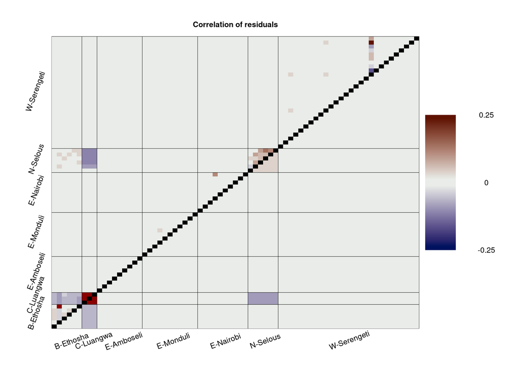

- Which population(s) does evalAdmix identify as having a bad fit?

### Evaluating covergence

There are several possible explanations for why the ADMIXTURE model fit is bad. The two most common reasons are 1) The choice of K is sub-optimal, and 2) the algorithm has not converged to the globally best solution. ADMIXTURE tries to find the combination of parameters than maximizes the log likelihoods. However, the algorithm does not always find the optimal solution when the likelhoood surface is not concave as illustated below.

[figure not shown]

To test for convergence (i.e. reason (2) mentioned above), we can test many different starting points. If many different runs with different starting points consistently lead to the same best log likelihood, then ADMIXTURE has very likely found the global optimal soluation.

To save time, we have pre-run ADMIXTURE using 10 other seeds. The results are found in the folder multiRunK7.

```
K=7

# mkdir -p multiRunK$K
# for seed in 1 2 3 4 5 6 7 8 9 10
# do
# admixture --seed $seed -j70 blue_wildebeest_noLD.bed $K | tee multiRunK$K/blue_wildebeest_noLD.$K.log_$seed
# mv blue_wildebeest_noLD.$K.Q multiRunK$K/blue_wildebeest_noLD.$K.Q_$seed
# mv blue_wildebeest_noLD.$K.P multiRunK$K/blue_wildebeest_noLD.$K.P_$seed
# done

cp -r -sf ${RESULTS_PATH}/* .
ls multiRunK$K/*_[1-9]*
```

```
multiRunK7/blue_wildebeest_noLD.7.log_1
multiRunK7/blue_wildebeest_noLD.7.log_10
multiRunK7/blue_wildebeest_noLD.7.log_2
multiRunK7/blue_wildebeest_noLD.7.log_3
multiRunK7/blue_wildebeest_noLD.7.log_4
multiRunK7/blue_wildebeest_noLD.7.log_5
multiRunK7/blue_wildebeest_noLD.7.log_6
multiRunK7/blue_wildebeest_noLD.7.log_7
multiRunK7/blue_wildebeest_noLD.7.log_8
multiRunK7/blue_wildebeest_noLD.7.log_9
multiRunK7/blue_wildebeest_noLD.7.P_1
multiRunK7/blue_wildebeest_noLD.7.P_10
multiRunK7/blue_wildebeest_noLD.7.P_2
multiRunK7/blue_wildebeest_noLD.7.P_3
multiRunK7/blue_wildebeest_noLD.7.P_4
multiRunK7/blue_wildebeest_noLD.7.P_5
multiRunK7/blue_wildebeest_noLD.7.P_6
multiRunK7/blue_wildebeest_noLD.7.P_7
multiRunK7/blue_wildebeest_noLD.7.P_8
multiRunK7/blue_wildebeest_noLD.7.P_9
multiRunK7/blue_wildebeest_noLD.7.Q_1
multiRunK7/blue_wildebeest_noLD.7.Q_10
multiRunK7/blue_wildebeest_noLD.7.Q_2
multiRunK7/blue_wildebeest_noLD.7.Q_3
multiRunK7/blue_wildebeest_noLD.7.Q_4
multiRunK7/blue_wildebeest_noLD.7.Q_5
multiRunK7/blue_wildebeest_noLD.7.Q_6
multiRunK7/blue_wildebeest_noLD.7.Q_7
multiRunK7/blue_wildebeest_noLD.7.Q_8
multiRunK7/blue_wildebeest_noLD.7.Q_9
```

We can extract the likelihoods for each of the 10 runs started with different seeds, and sort them according to their values.

```
%use Bash

grep ^Loglikelihood multiRunK7/blue_wildebeest_noLD.7.log_[1-9]* | sort -k 2 -t " "
```

```
multiRunK7/blue_wildebeest_noLD.7.log_5:Loglikelihood: -2907406.256689
multiRunK7/blue_wildebeest_noLD.7.log_1:Loglikelihood: -2907406.301438
multiRunK7/blue_wildebeest_noLD.7.log_4:Loglikelihood: -2907406.337752
multiRunK7/blue_wildebeest_noLD.7.log_10:Loglikelihood: -2907406.362582
multiRunK7/blue_wildebeest_noLD.7.log_7:Loglikelihood: -2907406.416679
multiRunK7/blue_wildebeest_noLD.7.log_8:Loglikelihood: -2915550.608364
multiRunK7/blue_wildebeest_noLD.7.log_9:Loglikelihood: -2917352.916092
multiRunK7/blue_wildebeest_noLD.7.log_6:Loglikelihood: -2917381.769511
multiRunK7/blue_wildebeest_noLD.7.log_3:Loglikelihood: -2934967.799459
multiRunK7/blue_wildebeest_noLD.7.log_2:Loglikelihood: -2935414.648161
```

- Which seed has the highest likelihood?
- Your first run used seed 0. Did your run find a local or global maximum (find the likeihood in the bottom of the output from the program when you ran it first, above).

Let's try to plot the results from the seed with the best likelihood.

```
options(repr.plot.width=17, repr.plot.height=4.5)


#read in code to plot admixture proportions ( plotAdmix function)
source("https://raw.githubusercontent.com/GenisGE/evalAdmix/master/visFuns.R")


# Read in inferred admixture proportions
q <- read.table("~/kenya2026/admixture/multiRunK7/blue_wildebeest_noLD.7.Q_5")

#read in the population labels (first column of fam file)
pop <- read.table("~/kenya2026/admixture/blue_wildebeest_noLD.fam")[,1]

#make the plot.
plotAdmix(q,pop=pop,rotatelab=15,padj=0.15,cex.lab=1.4,col=2:8)
```

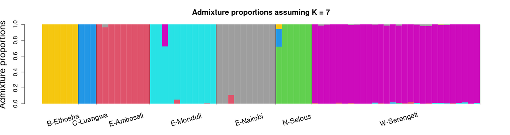

- Did the results improve?
- How many individuals can you find that are admixted between two subspecies?

Let's use evalAdmix to see if the model fit is better now.

```
evalAdmix -plink blue_wildebeest_noLD -fname multiRunK7/blue_wildebeest_noLD.7.P_5 \
-qname multiRunK7/blue_wildebeest_noLD.7.Q_5 -o blue_wildebeest_noLD.7.eval_5 -P 10
```

```
evalAdmix version 0.962
evalAdmix -plink blue_wildebeest_noLD -fname multiRunK7/blue_wildebeest_noLD.7.P_5 -qname multiRunK7/blue_wildebeest_noLD.7.Q_5 -o blue_wildebeest_noLD.7.eval_5 -P 10
	-> Will assume these are the plink files:
		bed: blue_wildebeest_noLD.bed
		bim: blue_wildebeest_noLD.bim
		fam: blue_wildebeest_noLD.fam
	-> Plink file contains 37576 autosomale SNPs
	-> reading genotypes 	-> Allocated: 0.005 gig memory
 - done
		->K=7	nSites=37576	nInd=73
opening : multiRunK7/blue_wildebeest_noLD.7.Q_5 with x=73 y=7
opening : multiRunK7/blue_wildebeest_noLD.7.P_5 with x=37576 y=7
Going to calcualte normal residuals
Finished calculating normal residuals
Correcting frequencies with 10 threads...
Finished, going to write all correlations
Correlation matrix has been written to blue_wildebeest_noLD.7.eval_5
	[ALL done] cpu-time used =  21.14 sec
	[ALL done] walltime used =  3.00 sec
	[ALL done] results have been outputted to blue_wildebeest_noLD.7.eval_5
```

Let's plot the results

```
#make plot wide
library("repr")
options(repr.plot.width=17, repr.plot.height=12)

#read in code to plot admixture proportions ( plotAdmix function)
source("https://raw.githubusercontent.com/GenisGE/evalAdmix/master/visFuns.R")

#read in the population labels (first column of fam file)
pop <- read.table("~/kenya2026/admixture/blue_wildebeest_noLD.fam")[,1]

r <- as.matrix(read.table("~/kenya2026/admixture/blue_wildebeest_noLD.7.eval_5"))
plotCorRes(r, pop=pop, max_z = 0.25,rotatelabpop =20,adjlab = .05)
```

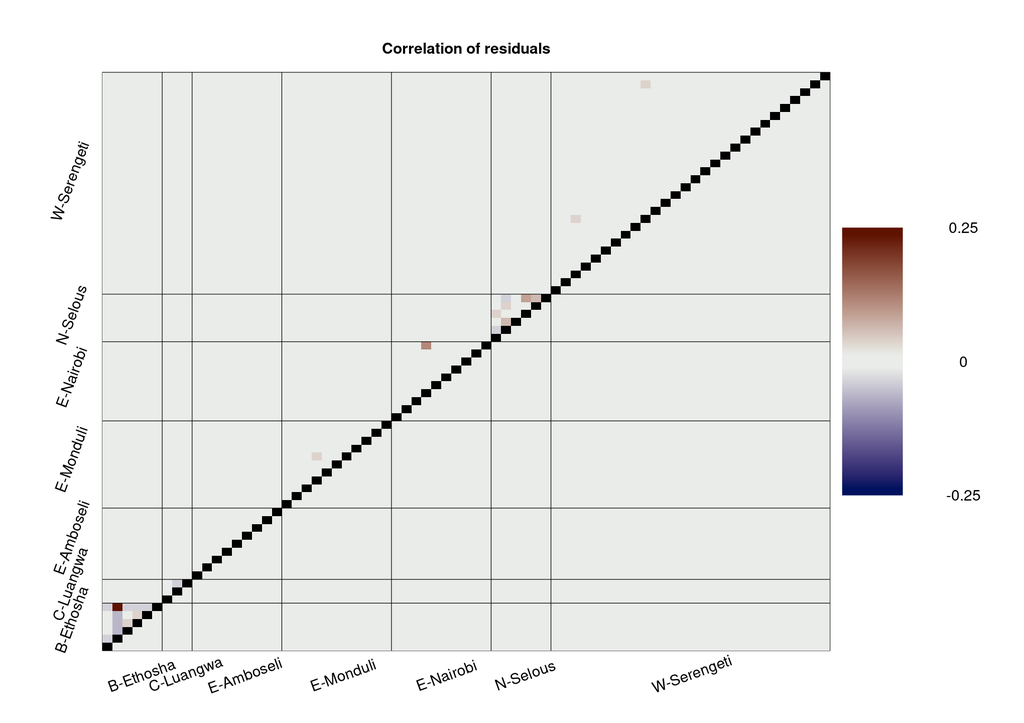

- How good is the fit this time?
- There are some few remaining pairs of individuals with a strong positive correlation. What do you think is the reason?

# Bonus exercise (only if you have time)

### Running ADMIXTURE for multiple K

This would take some time, so we have pre-computed it using the code below using 10 seeds per K value.

```
mkdir -p allK
# for K in 1 2 3 4 5 6 7
# do
#   for seed in 1 2 3 4 5 6 7 8 9 10
#   do
#     admixture --seed $seed -j70 blue_wildebeest_noLD.bed $K | tee allK/blue_wildebeest_noLD.$K.log_$seed
#     mv blue_wildebeest_noLD.$K.Q allK/blue_wildebeest_noLD.$K.Q_$seed
#     mv blue_wildebeest_noLD.$K.P allK/blue_wildebeest_noLD.$K.P_$seed
#   done
# done


ls allK/
```

```
blue_wildebeest_noLD.1.log_1     blue_wildebeest_noLD.4.P_6
blue_wildebeest_noLD.1.log_10    blue_wildebeest_noLD.4.P_7
blue_wildebeest_noLD.1.log_2     blue_wildebeest_noLD.4.P_8
blue_wildebeest_noLD.1.log_3     blue_wildebeest_noLD.4.P_9
blue_wildebeest_noLD.1.log_4     blue_wildebeest_noLD.4.P_best
blue_wildebeest_noLD.1.log_5     blue_wildebeest_noLD.4.Q_1
blue_wildebeest_noLD.1.log_6     blue_wildebeest_noLD.4.Q_10
blue_wildebeest_noLD.1.log_7     blue_wildebeest_noLD.4.Q_2
blue_wildebeest_noLD.1.log_8     blue_wildebeest_noLD.4.Q_3
blue_wildebeest_noLD.1.log_9     blue_wildebeest_noLD.4.Q_4
blue_wildebeest_noLD.1.log_best  blue_wildebeest_noLD.4.Q_5
blue_wildebeest_noLD.1.P_1       blue_wildebeest_noLD.4.Q_6
blue_wildebeest_noLD.1.P_10      blue_wildebeest_noLD.4.Q_7
blue_wildebeest_noLD.1.P_2       blue_wildebeest_noLD.4.Q_8
blue_wildebeest_noLD.1.P_3       blue_wildebeest_noLD.4.Q_9
blue_wildebeest_noLD.1.P_4       blue_wildebeest_noLD.4.Q_best
blue_wildebeest_noLD.1.P_5       blue_wildebeest_noLD.5.log_1
blue_wildebeest_noLD.1.P_6       blue_wildebeest_noLD.5.log_10
blue_wildebeest_noLD.1.P_7       blue_wildebeest_noLD.5.log_2
blue_wildebeest_noLD.1.P_8       blue_wildebeest_noLD.5.log_3
blue_wildebeest_noLD.1.P_9       blue_wildebeest_noLD.5.log_4
blue_wildebeest_noLD.1.P_best    blue_wildebeest_noLD.5.log_5
blue_wildebeest_noLD.1.Q_1       blue_wildebeest_noLD.5.log_6
blue_wildebeest_noLD.1.Q_10      blue_wildebeest_noLD.5.log_7
blue_wildebeest_noLD.1.Q_2       blue_wildebeest_noLD.5.log_8
blue_wildebeest_noLD.1.Q_3       blue_wildebeest_noLD.5.log_9
blue_wildebeest_noLD.1.Q_4       blue_wildebeest_noLD.5.log_best
blue_wildebeest_noLD.1.Q_5       blue_wildebeest_noLD.5.P_1
blue_wildebeest_noLD.1.Q_6       blue_wildebeest_noLD.5.P_10
blue_wildebeest_noLD.1.Q_7       blue_wildebeest_noLD.5.P_2
blue_wildebeest_noLD.1.Q_8       blue_wildebeest_noLD.5.P_3
blue_wildebeest_noLD.1.Q_9       blue_wildebeest_noLD.5.P_4
blue_wildebeest_noLD.1.Q_best    blue_wildebeest_noLD.5.P_5
blue_wildebeest_noLD.2.log_1     blue_wildebeest_noLD.5.P_6
blue_wildebeest_noLD.2.log_10    blue_wildebeest_noLD.5.P_7
blue_wildebeest_noLD.2.log_2     blue_wildebeest_noLD.5.P_8
blue_wildebeest_noLD.2.log_3     blue_wildebeest_noLD.5.P_9
blue_wildebeest_noLD.2.log_4     blue_wildebeest_noLD.5.P_best
blue_wildebeest_noLD.2.log_5     blue_wildebeest_noLD.5.Q_1
blue_wildebeest_noLD.2.log_6     blue_wildebeest_noLD.5.Q_10
```

[output cut: 61 more lines]

```
blue_wildebeest_noLD.4.log_2     blue_wildebeest_noLD.7.P_8
blue_wildebeest_noLD.4.log_3     blue_wildebeest_noLD.7.P_9
blue_wildebeest_noLD.4.log_4     blue_wildebeest_noLD.7.P_best
blue_wildebeest_noLD.4.log_5     blue_wildebeest_noLD.7.Q_1
blue_wildebeest_noLD.4.log_6     blue_wildebeest_noLD.7.Q_10
blue_wildebeest_noLD.4.log_7     blue_wildebeest_noLD.7.Q_2
blue_wildebeest_noLD.4.log_8     blue_wildebeest_noLD.7.Q_3
blue_wildebeest_noLD.4.log_9     blue_wildebeest_noLD.7.Q_4
blue_wildebeest_noLD.4.log_best  blue_wildebeest_noLD.7.Q_5
blue_wildebeest_noLD.4.P_1       blue_wildebeest_noLD.7.Q_6
blue_wildebeest_noLD.4.P_10      blue_wildebeest_noLD.7.Q_7
blue_wildebeest_noLD.4.P_2       blue_wildebeest_noLD.7.Q_8
blue_wildebeest_noLD.4.P_3       blue_wildebeest_noLD.7.Q_9
blue_wildebeest_noLD.4.P_4       blue_wildebeest_noLD.7.Q_best
blue_wildebeest_noLD.4.P_5
```

For each K we have found the run with the highest likelihood and made a new file named blue_wildebeest_noLD.*.Q_best. Let's plot the best runs in R.

```
options(repr.plot.width=17, repr.plot.height=9)

l<-list.files("~/kenya2026/admixture/allK/",full=TRUE,pattern="blue_wildebeest_noLD\\.[2-7]\\.Q_best$")
files<-sort(l)
print(files)
# possible K
Kall <- 2:7

## read Qs
allQ <- list()
for(K in Kall)
    allQ[[K]]<-t(read.table(files[K-min(Kall)+1]))


source("https://raw.githubusercontent.com/popgenDK/admixturePlot/main/admixFun.R")

pop <- read.table("~/kenya2026/admixture/blue_wildebeest_noLD.fam")[,1]
palette("default")
palette(palette()[-1])
plotMulti(allQ,Kall=Kall,as.factor(pop))
```

```
[1] "/home/jupyter-thomas/kenya2026/admixture/allK//blue_wildebeest_noLD.2.Q_best"
[2] "/home/jupyter-thomas/kenya2026/admixture/allK//blue_wildebeest_noLD.3.Q_best"
[3] "/home/jupyter-thomas/kenya2026/admixture/allK//blue_wildebeest_noLD.4.Q_best"
[4] "/home/jupyter-thomas/kenya2026/admixture/allK//blue_wildebeest_noLD.5.Q_best"
[5] "/home/jupyter-thomas/kenya2026/admixture/allK//blue_wildebeest_noLD.6.Q_best"
[6] "/home/jupyter-thomas/kenya2026/admixture/allK//blue_wildebeest_noLD.7.Q_best"
K=2  3
```

```
N perm 2
N perm 2
N perm 2
4  N perm 6
N perm 6
N perm 6
N perm 6
5  N perm 24
N perm 24
N perm 24
N perm 24
N perm 24
6  N perm 120
N perm 120
N perm 120
N perm 120
N perm 120
N perm 120
7  N perm 720
N perm 720
N perm 720
N perm 720
N perm 720
N perm 720
N perm 720
```

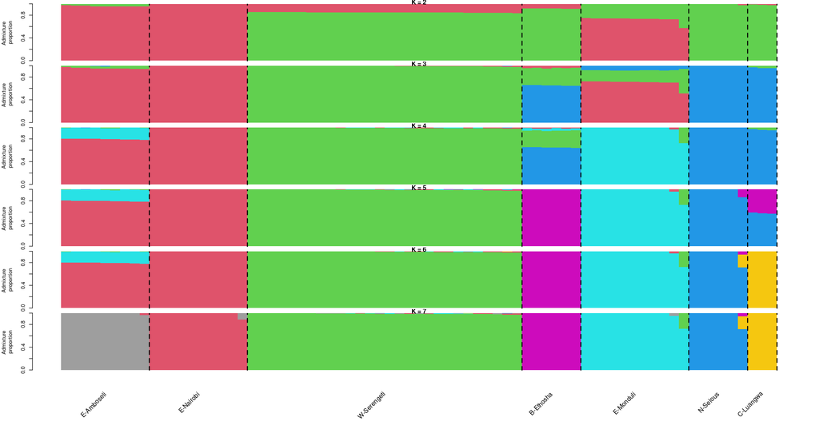

- What determines the order at which populations get their own ancestry compoment? In other words, is there a logic to which populations distinguishable at lower K?
- Which K is the best one?

Lets use evalAdmix to evalute the fit for each choice of K

```
K=2

for K in 1 2 3 4 5 6 7
  do
    echo ---- Running for K=$K -----------------------
    evalAdmix -plink blue_wildebeest_noLD -fname ~/kenya2026/admixture/allK/blue_wildebeest_noLD.$K.P_best \
    -qname ~/kenya2026/admixture/allK/blue_wildebeest_noLD.$K.Q_best -o blue_wildebeest_noLD.$K.eval_best -P 10
  done
```

```
---- Running for K=1 -----------------------
evalAdmix version 0.962
evalAdmix -plink blue_wildebeest_noLD -fname /home/jupyter-thomas/kenya2026/admixture/allK/blue_wildebeest_noLD.1.P_best -qname /home/jupyter-thomas/kenya2026/admixture/allK/blue_wildebeest_noLD.1.Q_best -o blue_wildebeest_noLD.1.eval_best -P 10
	-> Will assume these are the plink files:
		bed: blue_wildebeest_noLD.bed
		bim: blue_wildebeest_noLD.bim
		fam: blue_wildebeest_noLD.fam
	-> Plink file contains 37576 autosomale SNPs
	-> reading genotypes 	-> Allocated: 0.005 gig memory
 - done
		->K=1	nSites=37576	nInd=73
opening : /home/jupyter-thomas/kenya2026/admixture/allK/blue_wildebeest_noLD.1.Q_best with x=73 y=1
opening : /home/jupyter-thomas/kenya2026/admixture/allK/blue_wildebeest_noLD.1.P_best with x=37576 y=1
Going to calcualte normal residuals
Finished calculating normal residuals
Correcting frequencies with 10 threads...
Finished, going to write all correlations
Correlation matrix has been written to blue_wildebeest_noLD.1.eval_best
	[ALL done] cpu-time used =  8.73 sec
	[ALL done] walltime used =  1.00 sec
	[ALL done] results have been outputted to blue_wildebeest_noLD.1.eval_best
---- Running for K=2 -----------------------
evalAdmix version 0.962
evalAdmix -plink blue_wildebeest_noLD -fname /home/jupyter-thomas/kenya2026/admixture/allK/blue_wildebeest_noLD.2.P_best -qname /home/jupyter-thomas/kenya2026/admixture/allK/blue_wildebeest_noLD.2.Q_best -o blue_wildebeest_noLD.2.eval_best -P 10
	-> Will assume these are the plink files:
		bed: blue_wildebeest_noLD.bed
		bim: blue_wildebeest_noLD.bim
		fam: blue_wildebeest_noLD.fam
	-> Plink file contains 37576 autosomale SNPs
	-> reading genotypes 	-> Allocated: 0.005 gig memory
 - done
		->K=2	nSites=37576	nInd=73
opening : /home/jupyter-thomas/kenya2026/admixture/allK/blue_wildebeest_noLD.2.Q_best with x=73 y=2
opening : /home/jupyter-thomas/kenya2026/admixture/allK/blue_wildebeest_noLD.2.P_best with x=37576 y=2
Going to calcualte normal residuals
Finished calculating normal residuals
Correcting frequencies with 10 threads...
Finished, going to write all correlations
Correlation matrix has been written to blue_wildebeest_noLD.2.eval_best
	[ALL done] cpu-time used =  10.71 sec
```

[output cut: 92 more lines]

```
		fam: blue_wildebeest_noLD.fam
	-> Plink file contains 37576 autosomale SNPs
	-> reading genotypes 	-> Allocated: 0.005 gig memory
 - done
		->K=7	nSites=37576	nInd=73
opening : /home/jupyter-thomas/kenya2026/admixture/allK/blue_wildebeest_noLD.7.Q_best with x=73 y=7
opening : /home/jupyter-thomas/kenya2026/admixture/allK/blue_wildebeest_noLD.7.P_best with x=37576 y=7
Going to calcualte normal residuals
Finished calculating normal residuals
Correcting frequencies with 10 threads...
Finished, going to write all correlations
Correlation matrix has been written to blue_wildebeest_noLD.7.eval_best
	[ALL done] cpu-time used =  21.14 sec
	[ALL done] walltime used =  3.00 sec
	[ALL done] results have been outputted to blue_wildebeest_noLD.7.eval_best
```

Lets plot the results in R

```
#make plot wide
library("repr")

#read in code to plot admixture proportions ( plotAdmix function)
source("https://raw.githubusercontent.com/GenisGE/evalAdmix/master/visFuns.R")

#read in the population labels (first column of fam file)
pop <- read.table("~/kenya2026/admixture/blue_wildebeest_noLD.fam")[,1]
    options(repr.plot.width=14, repr.plot.height=4)

# Read in inferred admixture proportions
K=2
for(K in 2:7){

    q <- read.table(paste0("~/kenya2026/admixture/allK/blue_wildebeest_noLD.",K,".Q_best"))

    #read in the population labels (first column of fam file)
    pop <- read.table("~/kenya2026/admixture/blue_wildebeest_noLD.fam")[,1]

    #make the plot.

    plotAdmix(q,pop=pop,rotatelab=15,padj=0.15,cex.lab=1.4,col=2:8)

    options(repr.plot.width=14, repr.plot.height=4)

    r <- as.matrix(read.table(paste0("~/kenya2026/admixture/blue_wildebeest_noLD.",K,".eval_best")))

    plotCorRes(r, pop=pop, max_z = 0.25,rotatelabpop =20,adjlab = .05,title=paste0("Correlation of residuals with K=",K))
   options(repr.plot.width=14, repr.plot.height=11)

}
# for(K in 2:7){
#     r <- as.matrix(read.table(paste0("~/kenya2024/admixture/blue_wildebeest_noLD.",K,".eval_1")))
#     plotCorRes(r, pop=pop, max_z = 0.25,rotatelabpop =20,adjlab = .05,title=paste0("Correlation of residuals with K=",K))
# }
```

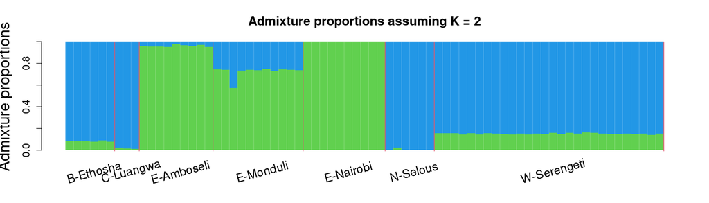

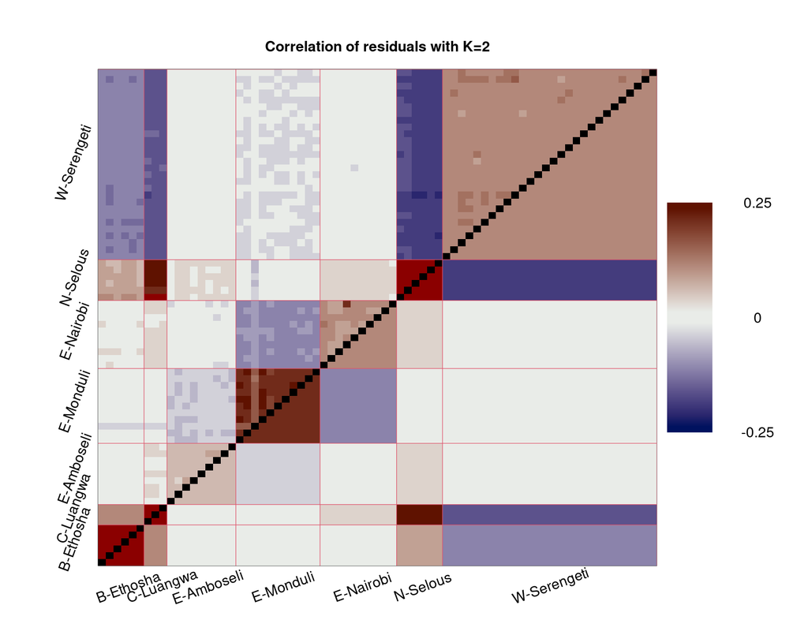

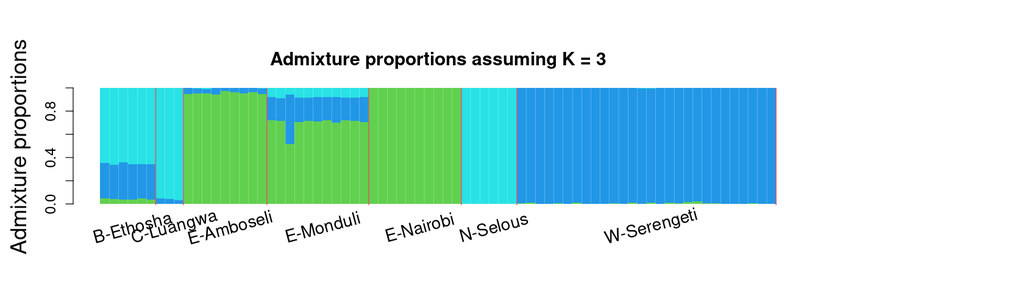

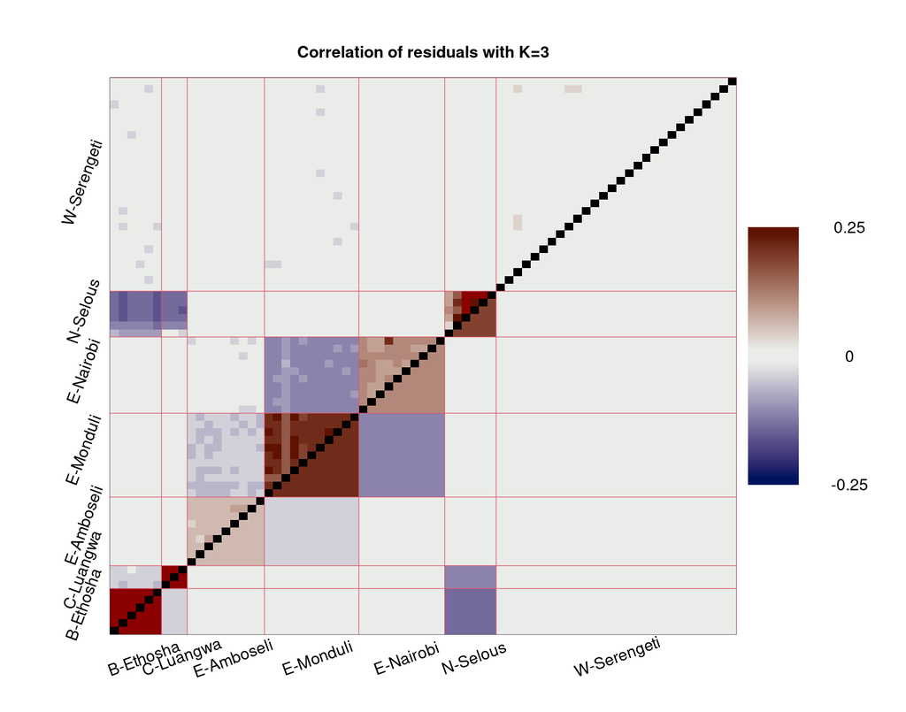

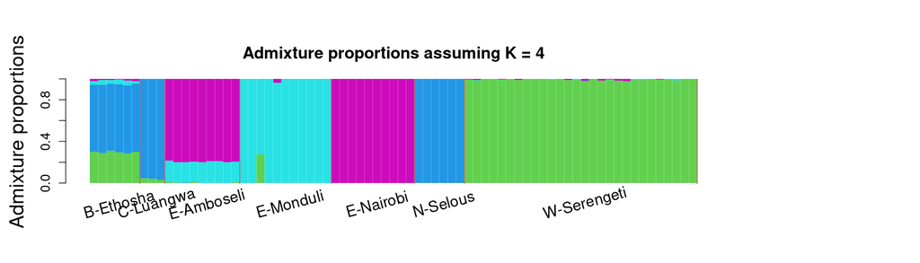

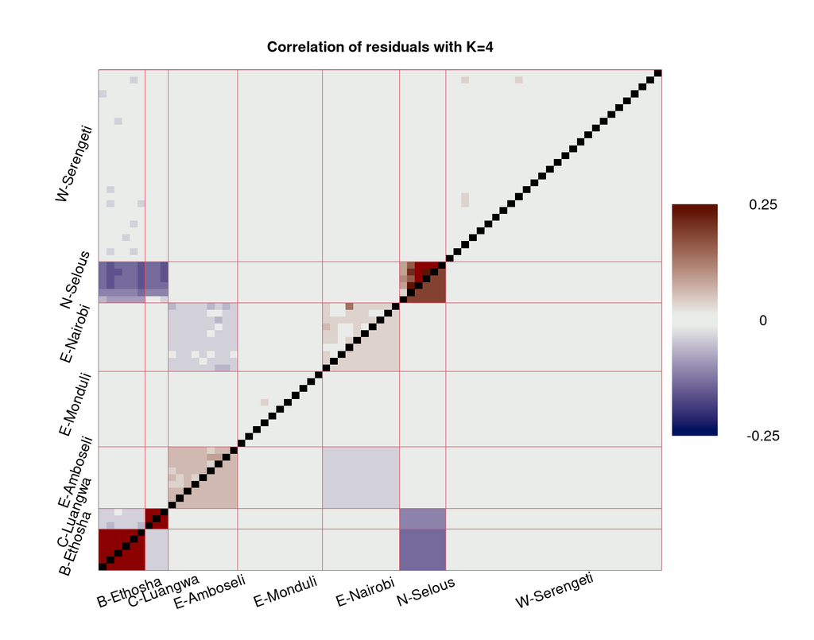

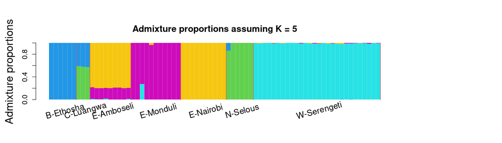

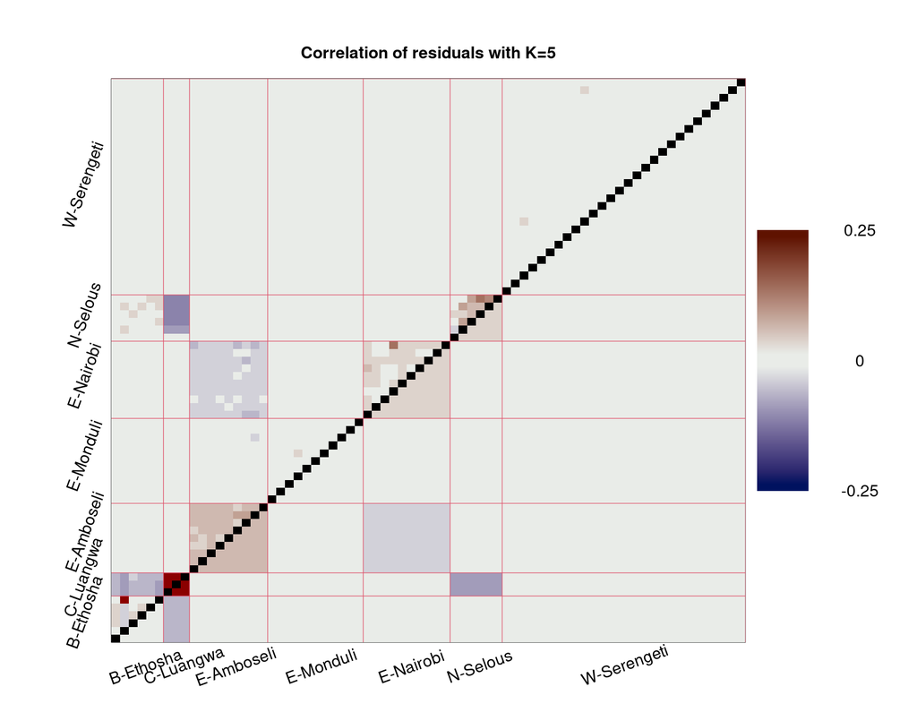

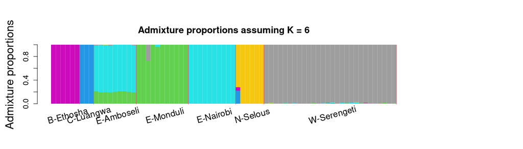

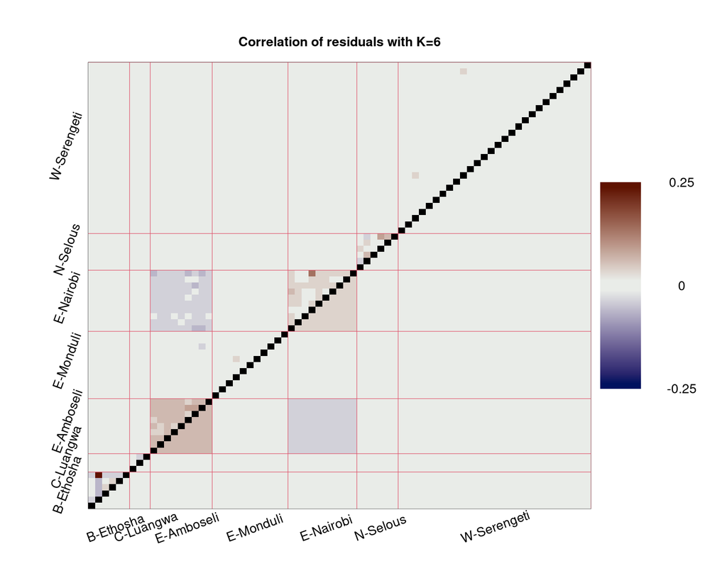

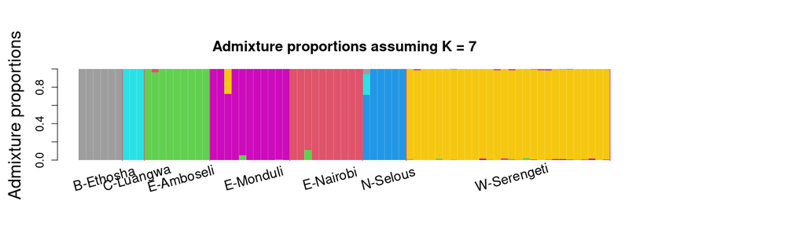

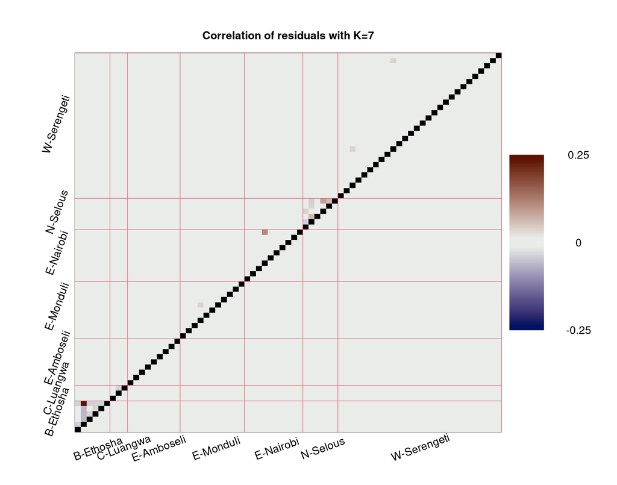

- How high a K is needed to have a good fit?
- at K=4 selous and luangwa have the same component. Can you then conclude that they are the same population? and how can you use evalAdmix to help you interpretation